# StatData 2 - Forelæsning d. 14/9-2017

[figure not shown]

[figure not shown]

[figure not shown]

[figure not shown]

[figure not shown]

[figure not shown]

[figure not shown]

[figure not shown]

[figure not shown]

[figure not shown]

[figure not shown]

[figure not shown]

[5 more figures not shown]

# Data

Indlæs data om volumen af venstre forkammer for hunde og undersøge strukturen af data.

```r
hunde <- read.table(file = "../data/hunde.txt", header = T)
head(hunde)
```

```
            race  wgt maxLA
1 Border_Terrier  9.2  6.07
2 Border_Terrier  6.9  4.67
3 Border_Terrier  7.7  4.40
4 Border_Terrier 11.0  4.48
5 Border_Terrier  6.3  2.78
6 Border_Terrier  6.7  3.60
```

# Tabeller

```r
table(hunde$race)
```

```
Border_Terrier   Grand_Danois       Labrador   Petit_Basset        Whippet
            24             19             17             20             17
```

```r
summary(hunde$maxLA)
```

```
   Min. 1st Qu.  Median    Mean 3rd Qu.    Max.
   2.78    7.44   12.57   15.86   19.49   55.63
```

```r
tapply(hunde$maxLA, hunde$race, summary)
```

```
$Border_Terrier
   Min. 1st Qu.  Median    Mean 3rd Qu.    Max.
  2.780   4.460   4.935   5.081   5.880   8.120

$Grand_Danois
   Min. 1st Qu.  Median    Mean 3rd Qu.    Max.
  21.35   29.56   34.48   35.47   39.48   55.63

$Labrador
   Min. 1st Qu.  Median    Mean 3rd Qu.    Max.
  12.22   17.50   19.08   18.92   19.68   26.73

$Petit_Basset
   Min. 1st Qu.  Median    Mean 3rd Qu.    Max.
  5.730   9.965  12.670  12.090  14.290  16.150

$Whippet
   Min. 1st Qu.  Median    Mean 3rd Qu.    Max.
   7.16    9.49   10.11   10.54   11.78   15.41
```

# 1-sidet ANOVA

### Fit model

Fit en 1-sidet ANOVA-model med **race** som faktor og udskriv de første 10 residualer.

```r
mod1 <- lm(maxLA ~ race, data = hunde)
resid(mod1)[1:10]
```

```
       1        2        3        4        5        6        7        8
 0.98875 -0.41125 -0.68125 -0.60125 -2.30125 -1.48125 -1.58125  1.51875
       9       10
 0.99875  2.90875
```

På de følgende *tabs* vises forskellige former for residualplot.

#### Konklusion (på baggrund af residualplots)

Residualplottene viser, at der er stor forskel på størrelsen af variationen inden for de forskellige grupper givet ved variablen ‘race’. Jo højere gruppegennemsnit for en race jo større variation inden for grupperne.

For at løse problemet prøver vi at transformere responsen. Det viser sig, at de log-transformerede værdier af maxLA i langt højere grad har ens varians inden for grupper.

### Residualplot

Box-plot af residualer mod **race**.

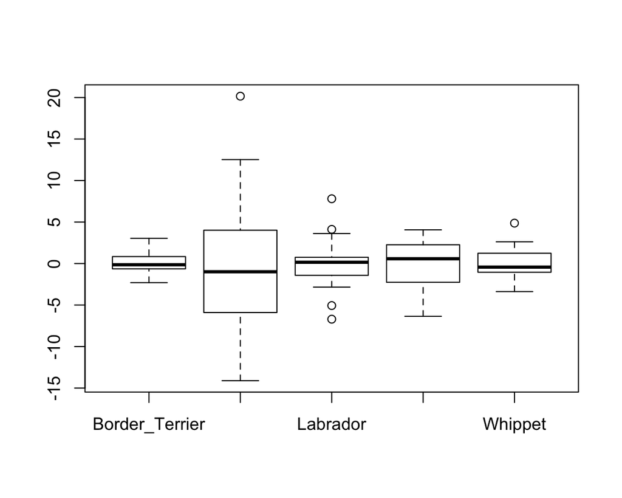

```r
plot(hunde$race, resid(mod1))
```

### Standardiserede residualer (1)

Box-plot af standardiserede residualer mod **race**.

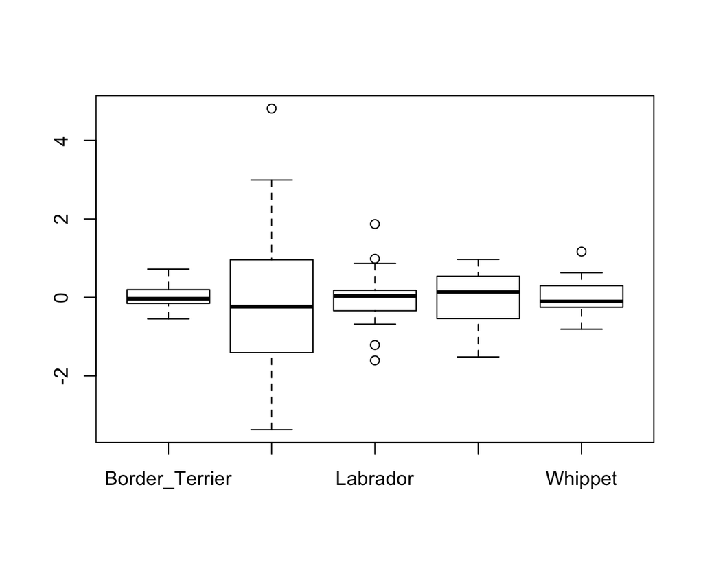

```r
plot(hunde$race, rstandard(mod1))
```

Er der samme varians på **maxLA** for alle racer?

### Standardiserede residualer (2)

Klassisk residualplot: standardiserede residualer plottet imod prædikterede værdier.

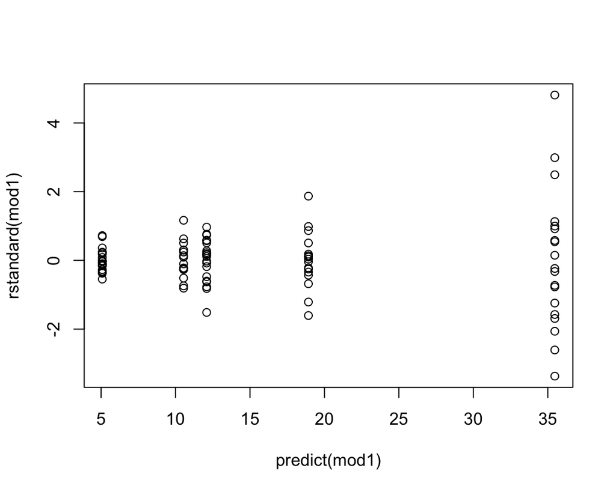

```r
plot(predict(mod1), rstandard(mod1))
```

Varierer størrelsen af de standardiserede residualer med de prædikterede værdier?

# 1-sidet ANOVA (log)

### Fit model

Vi benytter nu den naturlige logaritme til **maxLA** som responsvariabel i en 1-sidet variansanalysemodel.

```r
lmod1 <- lm(log(maxLA) ~ race, data = hunde)
```

### Residualplot

Et plot af de standardiserede residualer mod de prædikterede værdier viser, at antagelse om varianshomogenitet er langt mere rimelig, når vi benytter den logaritmetransformerede respons **log(maxLA)**.

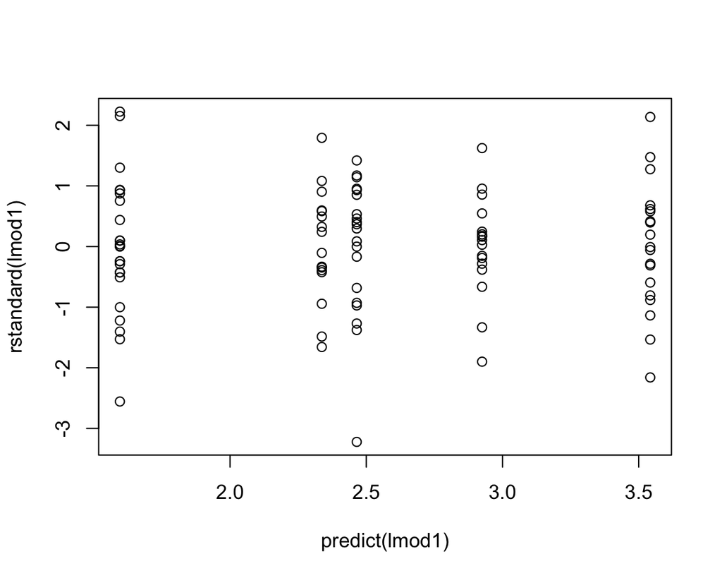

```r
plot(predict(lmod1), rstandard(lmod1))
```

### Estimater

```r
lmod1alt <- lm(log(maxLA) ~ race - 1, data = hunde)
summary(lmod1alt)
```

```
Call:
lm(formula = log(maxLA) ~ race - 1, data = hunde)

Residuals:
     Min       1Q   Median       3Q      Max
-0.71922 -0.09587  0.00793  0.13221  0.49884

Coefficients:
                   Estimate Std. Error t value Pr(>|t|)
raceBorder_Terrier  1.59549    0.04675   34.13   <2e-16 ***
raceGrand_Danois    3.54233    0.05254   67.42   <2e-16 ***
raceLabrador        2.92504    0.05555   52.66   <2e-16 ***
racePetit_Basset    2.46494    0.05121   48.13   <2e-16 ***
raceWhippet         2.33674    0.05555   42.07   <2e-16 ***
---
Signif. codes:  0 '***' 0.001 '**' 0.01 '*' 0.05 '.' 0.1 ' ' 1

Residual standard error: 0.229 on 92 degrees of freedom
Multiple R-squared:  0.9927,    Adjusted R-squared:  0.9923
F-statistic:  2514 on 5 and 92 DF,  p-value: < 2.2e-16
```

#### Fortolkning

Man skal være opmærksom på, at estimaterne angiver den forventede værdi (=middelværdien) af **log(maxLA)**.

Ofte vil man tilbagetransformere resultatet ved at tage eksponentialfunktionen (=invers logaritme) til estimaterne. Det tilbagetransformerede estimat for gruppen **Labrador** bliver 18.63.

Det tilbagetransformerede estimat *kan ikke fortolkes som middelværdien* af **maxLA** for gruppen **Labrador**. Man kan dog i dette tilbage tænke på det tilbagetransformerede estimat som et estimat for median-værdien af **maxLA**.

### QQ-plot

Desuden undersøges vha. et qq-plot om de standardisere residualer kan antages at følge en normalfordeling (kig efter en struktur omkring en ret linje med skæring 0 og hældning 1)

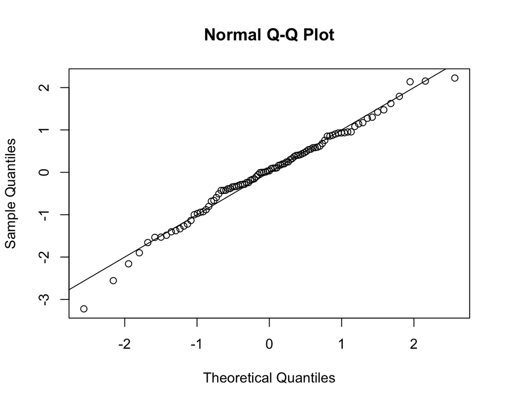

```r
qqnorm(rstandard(lmod1)) ### ret linje med hældning 1 ?
abline(0,1)
```

### QQ-plot (simulerede data)

For at vurdere, om afvigelserne fra den rette linje på QQ-plottet er større end forventet, så kan man sammenligne med et QQ-plot for simulerede data.

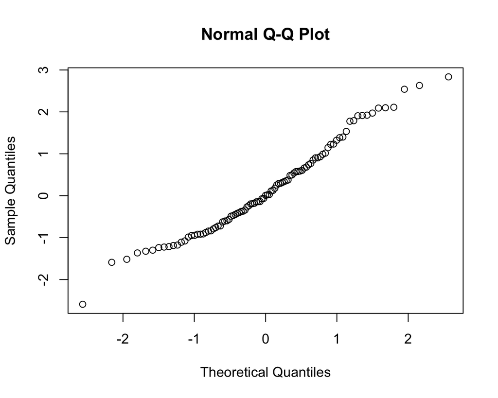

```r
qqnorm(rnorm(97)) ### sammenlign med simulerede data fra en perfekt situation
```

### Box-Cox

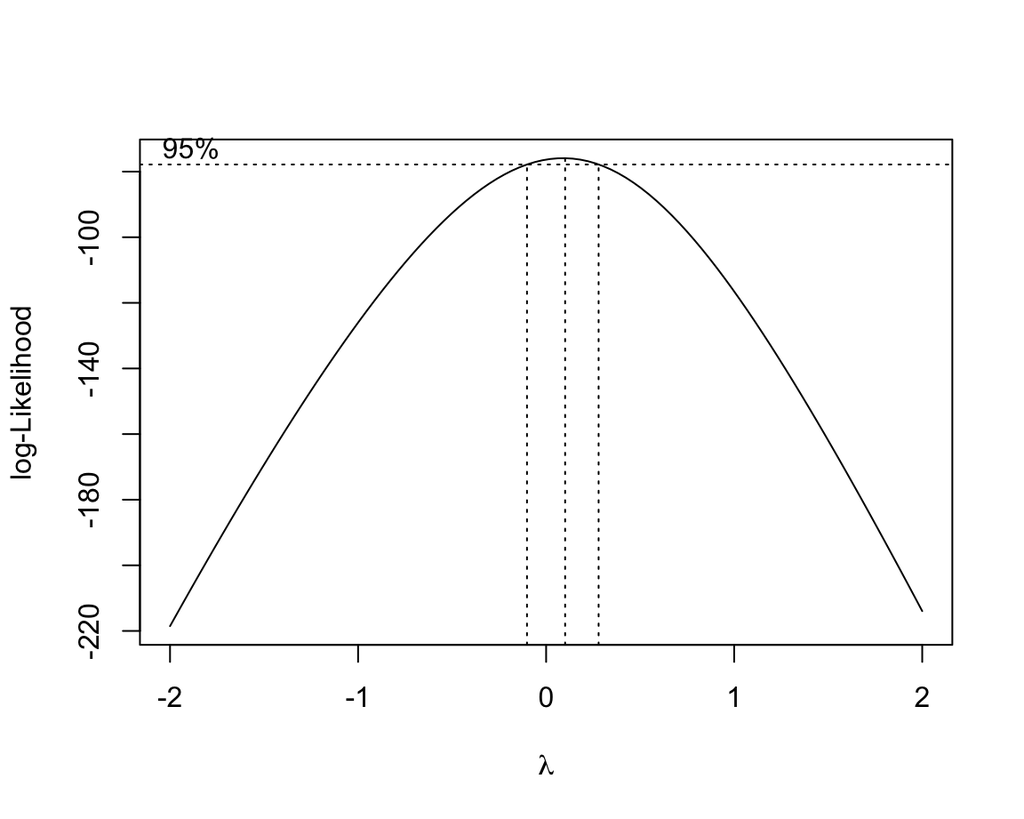

```r
library(MASS)
boxcox(mod1)
```

Et Box-Cox plot giver et fingerpeg om den bedste transformation af data.

Fortolkning:

- lambda = 1: ingen transformation
- lambda = 0: log-transformation
- lamdba = 1/2: kvadratrodstransformation

### Variansinhomogenitet

Det er (naturligvis) muligt at lave ensidet variansanalyse, hvor der ikke er samme varians i alle grupper, og det er altid en god ide at sammenligne resultaterne ved brug af forskellige metoder/modeller, der alle er valide.

```r
oneway.test(maxLA ~ race, data = hunde, var.equal = FALSE)
```

```
    One-way analysis of means (not assuming equal variances)

data:  maxLA and race
F = 136.62, num df = 4.000, denom df = 40.312, p-value < 2.2e-16
```

Der findes et par klassiske metoder til formelt at teste, om der er samme varians i alle grupper

```r
with(hunde, bartlett.test(maxLA ~ race))
```

```
    Bartlett test of homogeneity of variances

data:  maxLA by race
Bartlett's K-squared = 78.132, df = 4, p-value = 4.331e-16
```

```r
library(car)
leveneTest(y = hunde$maxLA, g = hunde$race)
```

```
Levene's Test for Homogeneity of Variance (center = median)
      Df F value    Pr(>F)
group  4  11.735 9.607e-08 ***
      92
---
Signif. codes:  0 '***' 0.001 '**' 0.01 '*' 0.05 '.' 0.1 ' ' 1
```

# Lineær regression

### Modeller med **wgt** som kovariat (numerisk)

```r
lmodlin <- lm(log(maxLA) ~ wgt, data = hunde) ### lin regression
```

### Residualplot (1)

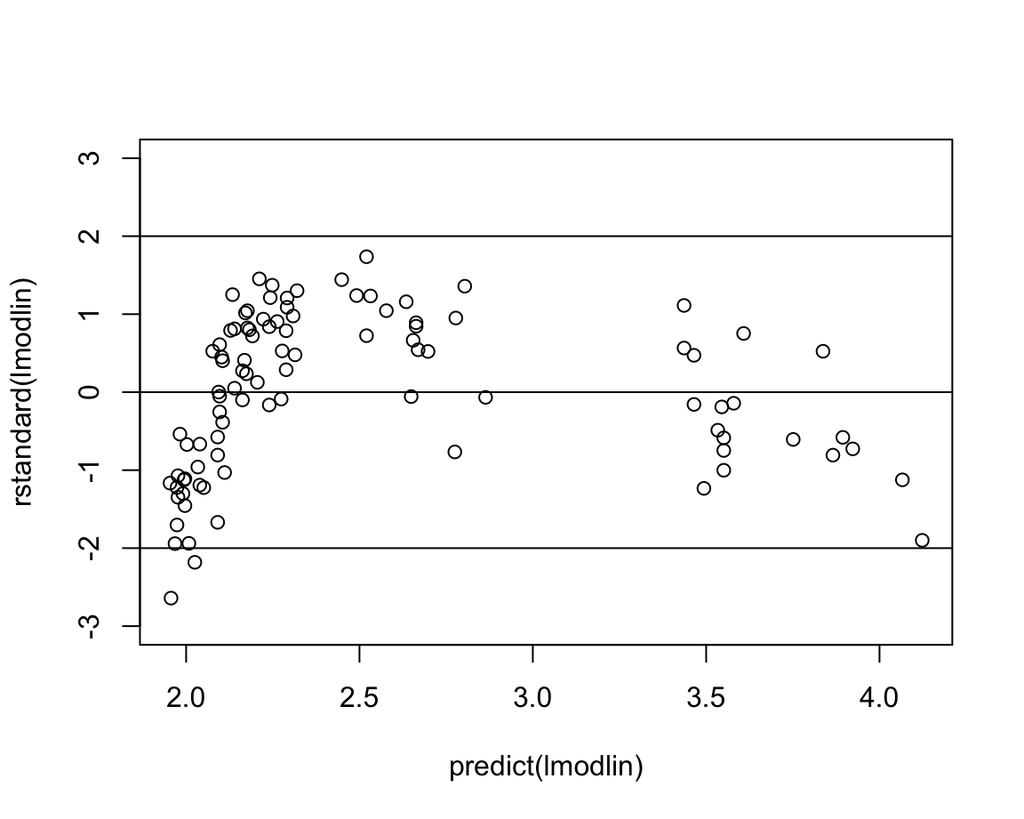

```r
plot(predict(lmodlin), rstandard(lmodlin), ylim = c(-3,3))
abline(h=c(-2,0,2))
```

### Residualplot (2)

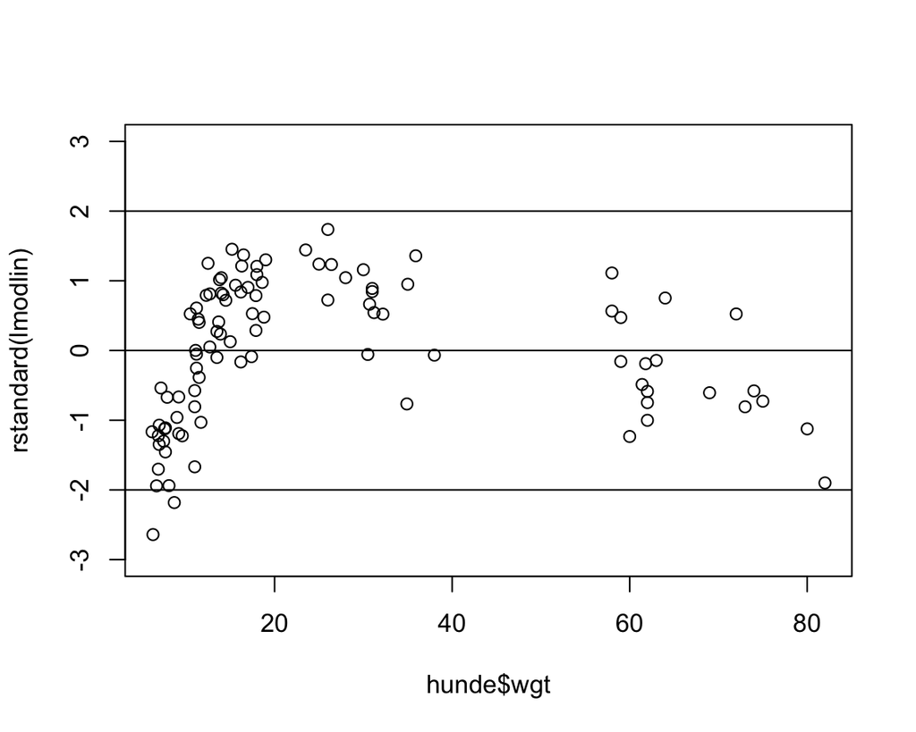

```r
plot(hunde$wgt, rstandard(lmodlin), ylim = c(-3,3))
abline(h=c(-2,0,2))
```

# Kvadratisk regression

### Kvadratisk model i **wgt**

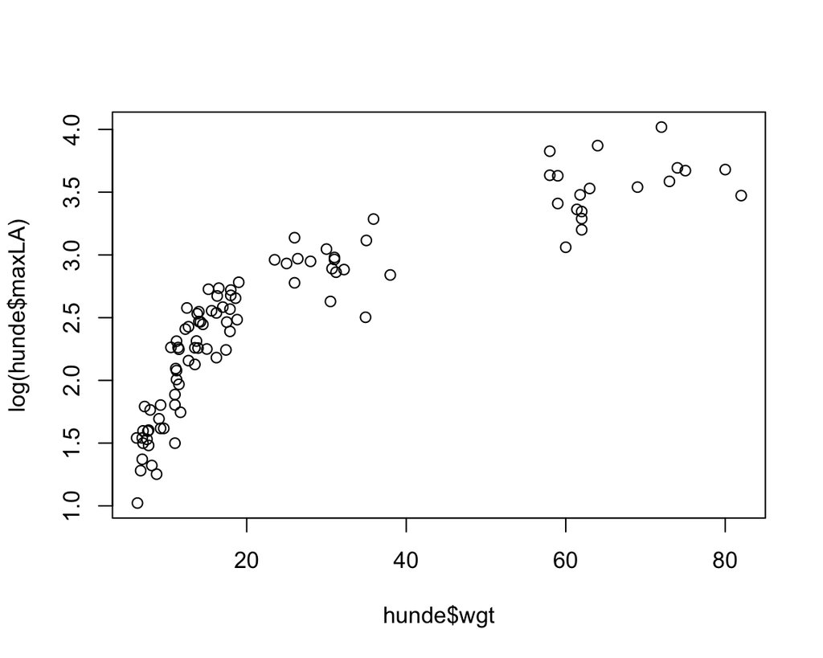

```r
lmodkvad <- lm(log(maxLA) ~ wgt + I(wgt^2), data = hunde) ### lin regression
plot(hunde$wgt, log(hunde$maxLA))
```

### residualplot (1)

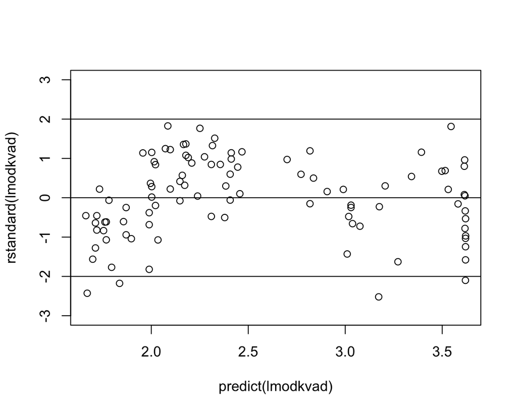

```r
plot(predict(lmodkvad), rstandard(lmodkvad), ylim = c(-3,3))
abline(h=c(-2,0,2))
```

### residualplot (2)

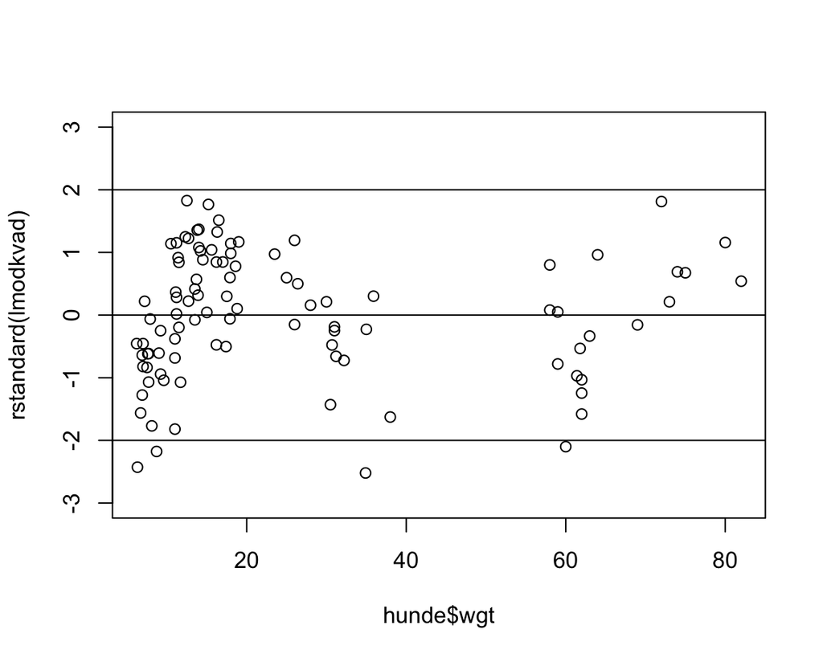

```r
plot(hunde$wgt, rstandard(lmodkvad), ylim = c(-3,3))
abline(h=c(-2,0,2))
```

# Log-log regression

### log-log model

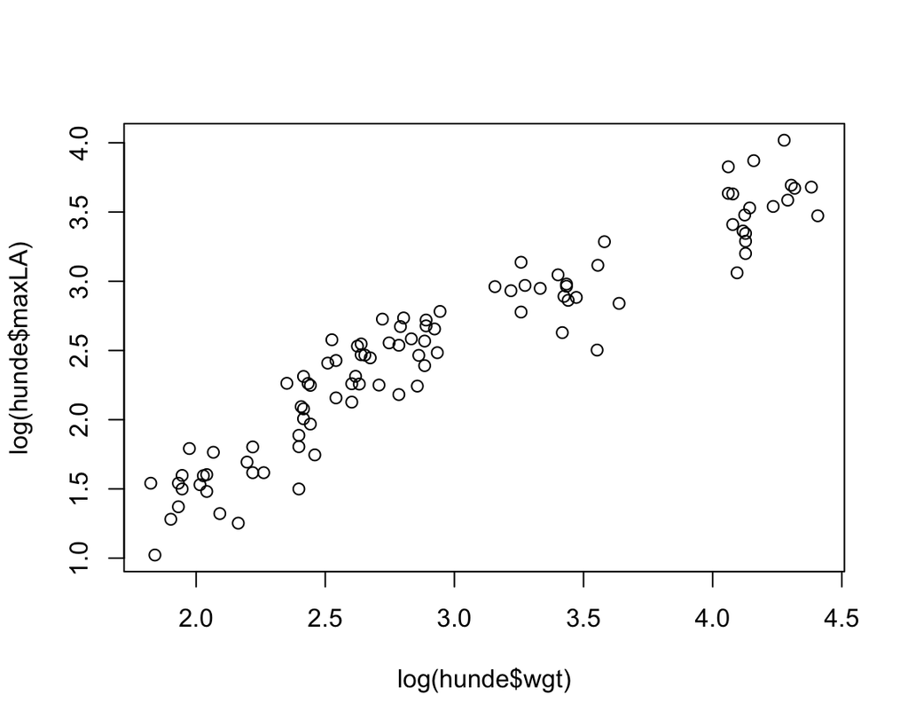

```r
llmod <- lm(log(maxLA) ~ log(wgt), data = hunde) ### lin regression
plot(log(hunde$wgt), log(hunde$maxLA))
```

Det virker ikke helt urimeligt at modellere sammenhængen mellem **maxLA** og **wgt** med en lineær sammenhæng, hvis vi transformerer begge variable med den naturlige logaritme først.

### Residualplot (1)

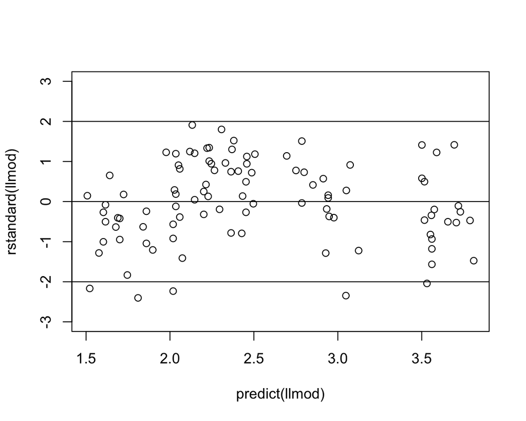

```r
plot(predict(llmod), rstandard(llmod), ylim = c(-3,3))
abline(h=c(-2,0,2))
```

### Residualplot (2)

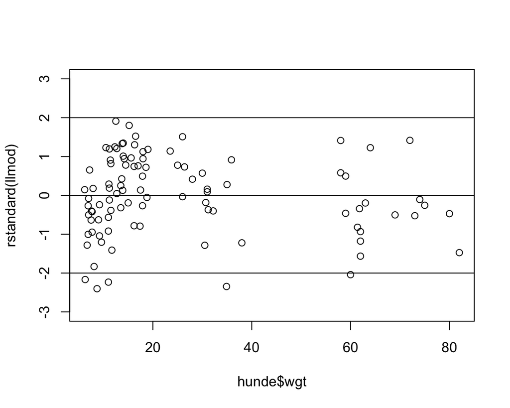

```r
plot(hunde$wgt, rstandard(llmod), ylim = c(-3,3))
abline(h=c(-2,0,2))
```

### QQ-plot

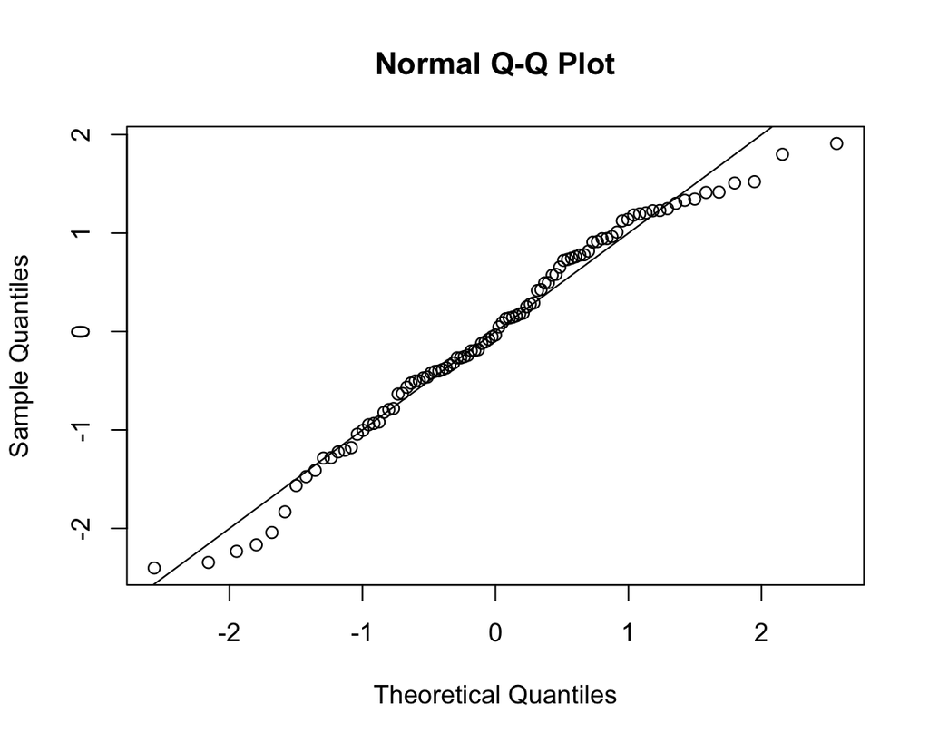

```r
qqnorm(rstandard(llmod))
abline(0, 1)
```